# Análise Exploratória de Dados - Dados Turísticos Macroeconômicos

Gabriel Rodrigues

2026-05-01

```r
setwd('/home/gabrielr/Documentos/UFMG/2026.1/ICD/Prática/Projeto/Data-Science-Project/')
```

# Dados Macroeconômicos Turísticos Mundiais

Primeiramente, vamos importar os dados, tratá-los normalizar tipos e visualizar alguns pontos chave.

```r
# Carregando as bibliotecas principais
library(tidyverse)
# Lendo os dados brutos

df_turismo <- read.csv("Tourism Quality/Tourism Quality Data.csv", stringsAsFactors = T)

# Ajuste inicial de tipos de dados
df_turismo <- df_turismo %>%
  mutate(
    Ano = as.factor(Ano), # Transformando o Ano em fator (categoria)
    IncomeGroup = factor(IncomeGroup,
                         levels = c("Low income", "Lower middle income",
                                    "Upper middle income", "High income")) # Ordenando a renda
  )

# Visualização inicial da base final
glimpse(df_turismo)
```

```
## Rows: 333
## Columns: 24
## $ Sigla                                                      <fct> AGO, AGO, A…
## $ País                                                       <fct> Angola, Ang…
## $ Ano                                                        <fct> 2019, 2021,…
## $ Region                                                     <fct> Sub-Saharan…
## $ IncomeGroup                                                <fct> Lower middl…
## $ Continente                                                 <fct> AF, AF, AF,…
## $ Cultural.Demand                                            <dbl> 1.138445, 1…
## $ Cultural.Resources                                         <dbl> 1.209611, 1…
## $ Geographic.Dispersion                                      <dbl> 2.607143, 2…
## $ Natural.Resources                                          <dbl> 3.003402, 3…
## $ Natural.Demand                                             <dbl> 1.057587, 1…
## $ Non.Leisure.Resources                                      <dbl> 1.270534, 1…
## $ Non.Leisure.Demand                                         <dbl> 1.052973, 1…
## $ Openness.to.Tourism                                        <dbl> 2.199659, 2…
## $ Prioritization.of.Tourism                                  <dbl> 3.618593, 3…
## $ Air.Transport.Infrastructure                               <dbl> 2.226030, 2…
## $ Ground.and.Port.Infrastructure                             <dbl> 1.816664, 1…
## $ T.T.Employment.Multiplier                                  <dbl> 4.756657, 5…
## $ T.T.GDP.Multiplier                                         <dbl> 4.680924, 5…
## $ T.T.Government.Expenditure.....of.Government.Budget        <dbl> 1.672798, 1…
## $ T.T.High.Wage.Jobs......of.Employment.in.High.Wage.Sectors <dbl> 6.075938, 5…
## $ Domestic.T.T.spending.....of.Internal.T.T.Spending         <dbl> 64.45112, 8…
## $ T.T.industry.Share.of.GDP.....of.total.GDP                 <dbl> 1.3524970, …
## $ T.T.industry.GDP                                           <dbl> 1328.0020, …
```

```r
unique(df_turismo$Ano)
```

```
## [1] 2019 2021 2024
## Levels: 2019 2021 2024
```

## Notas metodológicas acerca da da natureza dos dados

Antes de adentrarmos nas análises exploratórias, é fundamental tecer comentários sobre a natureza estrutural deste dataset (Tourism Quality Data) e, consequentemente, sobre os limites das inferências que podem ser extraídas dele.

- **Unidade de análise Macro (País-Ano)**

Os dados trabalhados consistem em um painel macroeconômico. Nossa observação mínima não é o indivíduo, o viajante, ou empresas (dados analíticos), mas a entidade “País” ou “Território” em recortes temporais específicos (2019, 2021 e 2024) sob determinados critérios.

- **Microdados vs Macrodados**

Não é possível utilizar esta base para análises probabilísticas de comportamento individual (ex.: “qual a probabilidade de um turista gastar mais em um destino com mais recursos naturais?”). O dado individual foi sumarizado em indicadores consolidados pelo macro do país, como multiplicadores de emprego, demanda natural, dispersão geográfica etc.

- **Índices e Scores Padronizados**

A maioria das variáveis qualitativas presentes no dataset (Tourism Quality Data) já são estatísticas consolidadas sob a forma de scores numéricos.

- **Abordagem estatística adotada**

Cientes de tais premissas, as análises descritivas e inferenciais focarão em padrões sistêmicos. Utilizaremos matrizes de correlaão, análise de variância entre estados globais e modelos de regressão para entender como a infraestrutura e a priorização governamental se relacionam no macro com a geração de riqueza do setor de turismo.

### O que os dados nos permitem responder de nossas perguntas iniciais?

A estrutura atual do dataset é rica em variáveis de corte transversal (cross-section) e agregações categóricas. Portanto, a base é perfeitamente adequada para responder a perguntas focadas em perfis, correlações, agrupamentos e comparações estruturais.

Os dados suportam com melhor rigor estatístico as seguintes investigações propostas:

- **Comparações e Perfis Estruturais:** Questões sobre Diferenças regionais (África Subsaariana vs. Zona do Euro vs. Mercosul vs. BRICS…; França vs Inglaterra vs Rússia vs. Brasil), Impacto do IncomeGroup, e Turismo de lazer vs. negócios. Podemos utilizar Análise de Variância (ANOVA) e boxplots para provar se a renda ou a região definem categorias com comportamentos estatisticamente distintos.
- **Eficiência e Relações de Recursos:** Questões sobre Recursos vs. Demanda, Eficiência Econômica e Recursos Naturais vs. Culturais. Ao criarmos razões (ex: PIB / Recursos Naturais), podemos facilmente mapear quais países “fazem mais com menos” e identificar padrões de especialização (matrizes de correlação).
- **Modelagem e Agrupamentos:**

Além das análises descritivas e comparativas, também podemos utilizar técnicas simples de modelagem e agrupamento para explorar melhor os padrões presentes nos dados.

- **Relações entre variáveis:** Podemos investigar como diferentes indicadores se relacionam entre si. Por exemplo, é possível verificar se países com melhor infraestrutura turística tendem a apresentar maior receita ou demanda. Para isso, utilizamos ferramentas como a matriz de correlação e gráficos de dispersão.
- **Modelos de regressão (introdução):** Uma abordagem inicial é utilizar regressões lineares simples para avaliar se uma variável pode ajudar a explicar outra. Por exemplo, podemos testar se indicadores como investimento em turismo ou qualidade de serviços estão associados ao desempenho econômico do setor. É importante destacar que esses modelos indicam associação, não causalidade.
- **Agrupamento de países (clusters):** Também podemos aplicar técnicas de agrupamento, como o K-means, para identificar grupos de países com características semelhantes. Esses grupos podem revelar padrões interessantes, como países com alto investimento e baixa eficiência, ou países que obtêm bons resultados com menos recursos.
- Identificação de padrões e outliers: Essas abordagens permitem identificar tanto padrões gerais quanto casos atípicos (outliers), que podem representar países com desempenho muito acima ou abaixo do esperado em relação aos demais.

De forma geral, essas técnicas ajudam a organizar melhor a informação contida nos dados e a gerar hipóteses sobre o funcionamento do setor turístico em nível global.

### E o que eles não nos permitem responder?

Algumas das perguntas propostas exigem estruturas de dados que não possuímos (como séries temporais longas ou testes de causalidade controlados). Tentar respondê-las diretamente com esta base resultará em conclusões estatisticamente frágeis. As principais restrições recaem sobre:

- **Tendências Históricas e Mudanças Estruturais de Longo Prazo:** Perguntas sobre Evolução de demandas ao longo do tempo e Países mudando de perfil.
  - O porquê: possuímos apenas três recortes temporais (2019, 2021 e 2024). Em estatística, três pontos não configuram uma “tendência histórica”. O que os dados de fato mostram é o choque agudo da pandemia de COVID-19 (a queda em 2021 e a recuperação em 2024). Não é possível afirmar que um país sofreu uma “mudança estrutural de modelo de turismo”; ele apenas pode ter tido uma recuperação mais lenta ou rápida da crise sanitária.
- **Causalidade e Trade-offs Exclusivos:** Perguntas como Infraestrutura como fator limitante para crescimento e Trade-offs (investir em X reduz Y).
  - O porquê: correlação não implica causalidade. A base nos permite afirmar que “países com maior infraestrutura tendem a ter maior receita”, mas não prova que o investimento financeiro direto na infraestrutura causou a receita. Da mesma forma, encontrar uma correlação negativa entre duas variáveis não prova a existência de um trade-off consciente de políticas públicas (onde o governo escolheu tirar dinheiro de X para colocar em Y).
- **Convergência de Longo Prazo:** Pergunta sobre Países mais abertos convergem para níveis mais altos.
  - O porquê: novamente, a janela de 5 anos (atravessada por uma pandemia que fechou fronteiras artificialmente) impede uma análise de convergência real. Podemos, no máximo, avaliar a elasticidade da recuperação de países abertos versus fechados no pós-crise.

## Análises e plotagens

### Análise Descritiva e Tendências Centrais

#### Indicadores por Região

Primeiramente, vamos analisar de forma ampĺa a base de dados a partir de algumas médias e visualização da quantidade de outliers e visualizar o efeito pandemia e recuperação econômica posterior.

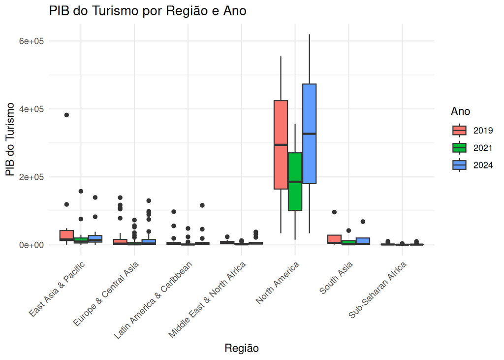

```r
ggplot(df_turismo, aes(x = Region, y = T.T.industry.GDP, fill = Ano)) +
  geom_boxplot(position = position_dodge(width = 0.8)) +
  theme_minimal() +
  theme(axis.text.x = element_text(angle = 45, hjust = 1)) +
  labs(
    title = "PIB do Turismo por Região e Ano",
    x = "Região",
    y = "PIB do Turismo"
  )
```

Como se pode observar, a pandemia impactou negativamente todos os países analisados no ano de 2021. Além disso, é interessante visualizar que o movimento de recuperação não foi homogêneo: a américa do norte recuperou mais agressivamente e, em movimento similar, somente um país da América do Latina recuperou da mesma forma.

```r
latin_rec <- df_turismo %>%
  filter(Region == "Latin America & Caribbean") %>%
  group_by(País, Ano) %>%
  summarise(
    gdp = mean(T.T.industry.GDP, na.rm = TRUE),
    .groups = "drop"
  ) %>%
  pivot_wider(names_from = Ano, values_from = gdp) %>%
  mutate(recuperacao = `2024` - `2021`) %>%
  arrange(desc(recuperacao))

glimpse(latin_rec)
```

```
## Rows: 20
## Columns: 5
## $ País        <fct> Mexico, Brazil, Argentina, Colombia, Chile, Dominican Repu…
## $ `2019`      <dbl> 97749.9500, 55845.5200, 19130.8800, 6518.7680, 9401.2590, …
## $ `2021`      <dbl> 48328.8500, 23642.5018, 8781.1250, 2081.5206, 4724.3660, 1…
## $ `2024`      <dbl> 116264.9150, 46116.2700, 18853.5786, 7464.2672, 8995.5020,…
## $ recuperacao <dbl> 67936.0650, 22473.7682, 10072.4536, 5382.7467, 4271.1360, …
```

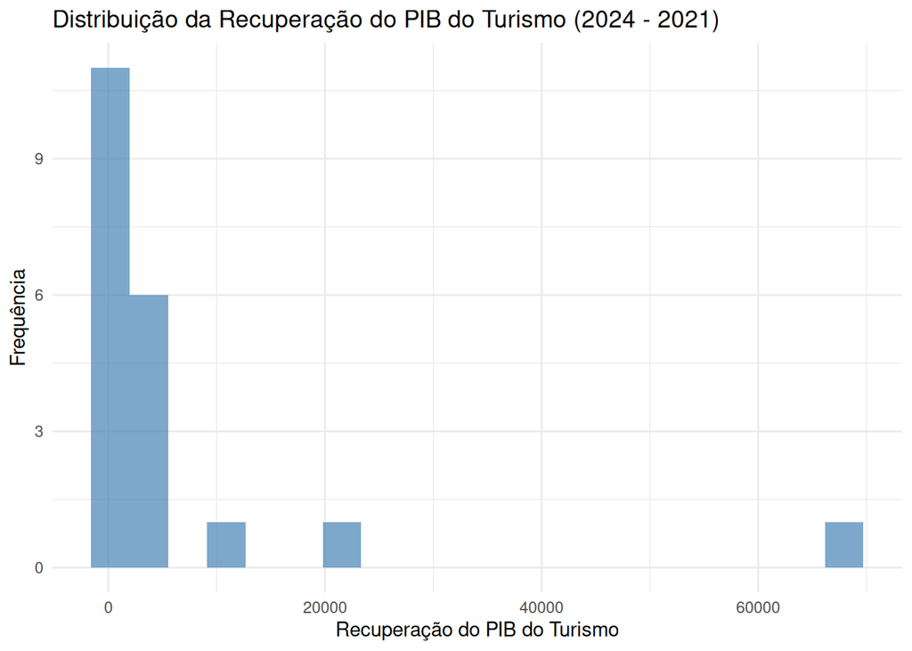

```r
ggplot(latin_rec, aes(x = recuperacao)) +
  geom_histogram(bins = 20, fill = "steelblue", alpha = 0.7) +
  theme_minimal() +
  labs(
    title = "Distribuição da Recuperação do PIB do Turismo (2024 - 2021)",
    x = "Recuperação do PIB do Turismo",
    y = "Frequência"
  )
```

```r
medias_regiao <- df_turismo %>%
  group_by(Region, Ano) %>%
  summarise(
    Cultural_Demand = mean(Cultural.Demand, na.rm = TRUE),
    Natural_Demand = mean(Natural.Demand, na.rm = TRUE),
    Non_Leisure_Demand = mean(Non.Leisure.Demand, na.rm = TRUE),
    GDP_Tourism = mean(T.T.industry.GDP, na.rm = TRUE)
  ) %>%
  pivot_longer(-c(Region, Ano), names_to = "Indicador", values_to = "Media")
```

[output not shown]